# Breast cancer Wisconsin dataset

## Executive summary

This project is based on the Wisconsin Breast cancer database. I used the version published on Kaggle by UCI Machine Leraning. The dataset is available under https://www.kaggle.com/uciml/breast-cancer-wisconsin-data.

The objectives of this analysis are to explore classification algorithms, and to demonstrate my python programming skills.

## Load the data, manage missing values

```python
#Import libraries
import pandas as pd
import numpy as np
import os
import time
import math

import matplotlib.pyplot as plt
import matplotlib as mpl

import seaborn as sns;
os.chdir('D:\data science\Breast cancer')
os.getcwd()
print(os.getcwd())
```

```
D:\data science\Breast cancer
```

```python
#load the data
data= pd.read_csv('data.csv')
print('The raw dataset contains ',data.shape[0], ' observations of ',data.shape[1], ' variables.')
```

```
The raw dataset contains  569  observations of  33  variables.
```

```python
#variables names and overview of the dataset
cols = data.columns
print(cols)
data.head(7)
```

```
Index(['id', 'diagnosis', 'radius_mean', 'texture_mean', 'perimeter_mean',
       'area_mean', 'smoothness_mean', 'compactness_mean', 'concavity_mean',
       'concave points_mean', 'symmetry_mean', 'fractal_dimension_mean',
       'radius_se', 'texture_se', 'perimeter_se', 'area_se', 'smoothness_se',
       'compactness_se', 'concavity_se', 'concave points_se', 'symmetry_se',
       'fractal_dimension_se', 'radius_worst', 'texture_worst',
       'perimeter_worst', 'area_worst', 'smoothness_worst',
       'compactness_worst', 'concavity_worst', 'concave points_worst',
       'symmetry_worst', 'fractal_dimension_worst', 'Unnamed: 32'],
      dtype='object')
```

|  | id | diagnosis | radius_mean | texture_mean | perimeter_mean | area_mean | smoothness_mean | compactness_mean | concavity_mean | concave points_mean | ... | texture_worst | perimeter_worst | area_worst | smoothness_worst | compactness_worst | concavity_worst | concave points_worst | symmetry_worst | fractal_dimension_worst | Unnamed: 32 |
| --- | --- | --- | --- | --- | --- | --- | --- | --- | --- | --- | --- | --- | --- | --- | --- | --- | --- | --- | --- | --- | --- |
| 0 | 842302 | M | 17.99 | 10.38 | 122.80 | 1001.0 | 0.11840 | 0.27760 | 0.3001 | 0.14710 | ... | 17.33 | 184.60 | 2019.0 | 0.1622 | 0.6656 | 0.7119 | 0.2654 | 0.4601 | 0.11890 | NaN |
| 1 | 842517 | M | 20.57 | 17.77 | 132.90 | 1326.0 | 0.08474 | 0.07864 | 0.0869 | 0.07017 | ... | 23.41 | 158.80 | 1956.0 | 0.1238 | 0.1866 | 0.2416 | 0.1860 | 0.2750 | 0.08902 | NaN |
| 2 | 84300903 | M | 19.69 | 21.25 | 130.00 | 1203.0 | 0.10960 | 0.15990 | 0.1974 | 0.12790 | ... | 25.53 | 152.50 | 1709.0 | 0.1444 | 0.4245 | 0.4504 | 0.2430 | 0.3613 | 0.08758 | NaN |
| 3 | 84348301 | M | 11.42 | 20.38 | 77.58 | 386.1 | 0.14250 | 0.28390 | 0.2414 | 0.10520 | ... | 26.50 | 98.87 | 567.7 | 0.2098 | 0.8663 | 0.6869 | 0.2575 | 0.6638 | 0.17300 | NaN |
| 4 | 84358402 | M | 20.29 | 14.34 | 135.10 | 1297.0 | 0.10030 | 0.13280 | 0.1980 | 0.10430 | ... | 16.67 | 152.20 | 1575.0 | 0.1374 | 0.2050 | 0.4000 | 0.1625 | 0.2364 | 0.07678 | NaN |
| 5 | 843786 | M | 12.45 | 15.70 | 82.57 | 477.1 | 0.12780 | 0.17000 | 0.1578 | 0.08089 | ... | 23.75 | 103.40 | 741.6 | 0.1791 | 0.5249 | 0.5355 | 0.1741 | 0.3985 | 0.12440 | NaN |
| 6 | 844359 | M | 18.25 | 19.98 | 119.60 | 1040.0 | 0.09463 | 0.10900 | 0.1127 | 0.07400 | ... | 27.66 | 153.20 | 1606.0 | 0.1442 | 0.2576 | 0.3784 | 0.1932 | 0.3063 | 0.08368 | NaN |

7 rows × 33 columns

```python
#manage missing data
missing = data.isnull().sum().sort_values(ascending=False)
print('missing values: ' ,missing.drop(missing[missing==0].index))
```

```
missing values:  Unnamed: 32    569
dtype: int64
```

**Missing Values:** I will remove the following variables:

- **id** brings no information for predictive purpose
- **Unnamed 32** does not contain any value

There are no other missing value.

```python
#removing variables
data = data.drop(['id', 'Unnamed: 32'],axis=1)
```

```python
data.describe()
```

|  | radius_mean | texture_mean | perimeter_mean | area_mean | smoothness_mean | compactness_mean | concavity_mean | concave points_mean | symmetry_mean | fractal_dimension_mean | ... | radius_worst | texture_worst | perimeter_worst | area_worst | smoothness_worst | compactness_worst | concavity_worst | concave points_worst | symmetry_worst | fractal_dimension_worst |
| --- | --- | --- | --- | --- | --- | --- | --- | --- | --- | --- | --- | --- | --- | --- | --- | --- | --- | --- | --- | --- | --- |
| count | 569.000000 | 569.000000 | 569.000000 | 569.000000 | 569.000000 | 569.000000 | 569.000000 | 569.000000 | 569.000000 | 569.000000 | ... | 569.000000 | 569.000000 | 569.000000 | 569.000000 | 569.000000 | 569.000000 | 569.000000 | 569.000000 | 569.000000 | 569.000000 |
| mean | 14.127292 | 19.289649 | 91.969033 | 654.889104 | 0.096360 | 0.104341 | 0.088799 | 0.048919 | 0.181162 | 0.062798 | ... | 16.269190 | 25.677223 | 107.261213 | 880.583128 | 0.132369 | 0.254265 | 0.272188 | 0.114606 | 0.290076 | 0.083946 |
| std | 3.524049 | 4.301036 | 24.298981 | 351.914129 | 0.014064 | 0.052813 | 0.079720 | 0.038803 | 0.027414 | 0.007060 | ... | 4.833242 | 6.146258 | 33.602542 | 569.356993 | 0.022832 | 0.157336 | 0.208624 | 0.065732 | 0.061867 | 0.018061 |
| min | 6.981000 | 9.710000 | 43.790000 | 143.500000 | 0.052630 | 0.019380 | 0.000000 | 0.000000 | 0.106000 | 0.049960 | ... | 7.930000 | 12.020000 | 50.410000 | 185.200000 | 0.071170 | 0.027290 | 0.000000 | 0.000000 | 0.156500 | 0.055040 |
| 25% | 11.700000 | 16.170000 | 75.170000 | 420.300000 | 0.086370 | 0.064920 | 0.029560 | 0.020310 | 0.161900 | 0.057700 | ... | 13.010000 | 21.080000 | 84.110000 | 515.300000 | 0.116600 | 0.147200 | 0.114500 | 0.064930 | 0.250400 | 0.071460 |
| 50% | 13.370000 | 18.840000 | 86.240000 | 551.100000 | 0.095870 | 0.092630 | 0.061540 | 0.033500 | 0.179200 | 0.061540 | ... | 14.970000 | 25.410000 | 97.660000 | 686.500000 | 0.131300 | 0.211900 | 0.226700 | 0.099930 | 0.282200 | 0.080040 |
| 75% | 15.780000 | 21.800000 | 104.100000 | 782.700000 | 0.105300 | 0.130400 | 0.130700 | 0.074000 | 0.195700 | 0.066120 | ... | 18.790000 | 29.720000 | 125.400000 | 1084.000000 | 0.146000 | 0.339100 | 0.382900 | 0.161400 | 0.317900 | 0.092080 |
| max | 28.110000 | 39.280000 | 188.500000 | 2501.000000 | 0.163400 | 0.345400 | 0.426800 | 0.201200 | 0.304000 | 0.097440 | ... | 36.040000 | 49.540000 | 251.200000 | 4254.000000 | 0.222600 | 1.058000 | 1.252000 | 0.291000 | 0.663800 | 0.207500 |

8 rows × 30 columns

## Exploratory data analysis

```python
#distribution of diagnosis

print(data.diagnosis.value_counts(normalize=True))
```

```
B    0.627417
M    0.372583
Name: diagnosis, dtype: float64
```

The dataset is relatively balanced with broadly 37% of observations being malignant

### Correlation studies

> We will first analyse pairwise correlations within the dataset. We will then analyse the relationship between the radius, perimeter and area variables. Then, we will analyse the relations between 'mean', 'se' and 'worst' measurement of the same quantities.

#### Pairwise correlations

```python
#Pairwise correlations

core = data.corr()
c1 = core.unstack()
c1=c1[(c1<1)&(abs(c1)>0.8)]#I set the cutout for high correlation at 80%
c1.sort_values(ascending = False).drop_duplicates()
```

```
radius_mean              perimeter_mean          0.997855
perimeter_worst          radius_worst            0.993708
radius_mean              area_mean               0.987357
perimeter_mean           area_mean               0.986507
radius_worst             area_worst              0.984015
area_worst               perimeter_worst         0.977578
perimeter_se             radius_se               0.972794
perimeter_mean           perimeter_worst         0.970387
radius_worst             radius_mean             0.969539
perimeter_mean           radius_worst            0.969476
radius_mean              perimeter_worst         0.965137
area_mean                radius_worst            0.962746
                         area_worst              0.959213
                         perimeter_worst         0.959120
radius_se                area_se                 0.951830
area_worst               perimeter_mean          0.941550
radius_mean              area_worst              0.941082
area_se                  perimeter_se            0.937655
concave points_mean      concavity_mean          0.921391
texture_worst            texture_mean            0.912045
concave points_mean      concave points_worst    0.910155
concavity_worst          compactness_worst       0.892261
                         concavity_mean          0.884103
compactness_mean         concavity_mean          0.883121
compactness_worst        compactness_mean        0.865809
concavity_mean           concave points_worst    0.861323
concave points_mean      perimeter_worst         0.855923
concave points_worst     concavity_worst         0.855434
perimeter_mean           concave points_mean     0.850977
compactness_mean         concave points_mean     0.831135
concave points_mean      radius_worst            0.830318
                         area_mean               0.823269
                         radius_mean             0.822529
concave points_worst     perimeter_worst         0.816322
compactness_mean         concavity_worst         0.816275
                         concave points_worst    0.815573
area_worst               area_se                 0.811408
fractal_dimension_worst  compactness_worst       0.810455
concave points_mean      area_worst              0.809630
smoothness_mean          smoothness_worst        0.805324
compactness_se           fractal_dimension_se    0.803269
                         concavity_se            0.801268
compactness_worst        concave points_worst    0.801080
area_mean                area_se                 0.800086
dtype: float64
```

There is a very high level of correlation within the dataset. The **radius / perimeter / area** are correlated. I would like to explore if there exists a quadatic relationship betwen radius and area. The **mean** and **worst** values are usually highly correlated for the same variable. **Concavity** and **concave points** variables are correlated. In a business case, I would engage with the front line team to explore if there is a more discriminant way to capture the information for those two variables.

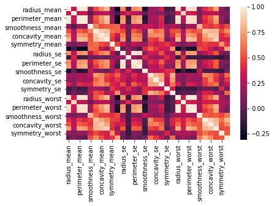

```python
sns.heatmap(core)
```

### Variable importance with a random forest

I fit a quick and dirty random forest to the dataset to get a feel of the variables importance

```python
from sklearn.ensemble import RandomForestClassifier
quickrf=RandomForestClassifier()
response = data['diagnosis']
variables = data.drop('diagnosis',axis=1)
quickrf.fit(variables,response)#fitted on entire dataset, because I do the train/test split later.
#I don't expect a huge ifference in terms of var importance
varimp  = pd.DataFrame(quickrf.feature_importances_,
                                   index = variables.columns,
                                    columns=['importance']).sort_values('importance',ascending=False)
varimp

#varimp.tail(5)
#plt.barh(varimp.index,varimp.importance)
```

|  | importance |
| --- | --- |
| perimeter_worst | 0.185149 |
| concavity_mean | 0.132544 |
| area_worst | 0.124324 |
| radius_worst | 0.096510 |
| concave points_worst | 0.085446 |
| concave points_mean | 0.084618 |
| area_se | 0.055956 |
| radius_se | 0.045154 |
| compactness_worst | 0.022669 |
| texture_mean | 0.017656 |
| concavity_worst | 0.017388 |
| texture_worst | 0.016281 |
| perimeter_mean | 0.015930 |
| symmetry_worst | 0.013344 |
| area_mean | 0.012704 |
| smoothness_worst | 0.012616 |
| radius_mean | 0.009426 |
| compactness_mean | 0.005675 |
| symmetry_se | 0.005392 |
| smoothness_se | 0.004791 |
| symmetry_mean | 0.004759 |
| concave points_se | 0.004627 |
| concavity_se | 0.004586 |
| texture_se | 0.004490 |
| fractal_dimension_worst | 0.004357 |
| fractal_dimension_mean | 0.004055 |
| fractal_dimension_se | 0.003085 |
| smoothness_mean | 0.002309 |
| perimeter_se | 0.002222 |
| compactness_se | 0.001937 |

The worst values have more importance

### Relationship between area, perimeter and radius

Let's explore the relationship between the area, perimeter and radius variables

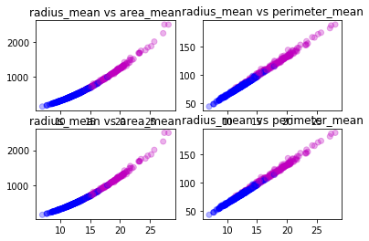

```python
fig, axes = plt.subplots(nrows=2, ncols=2)

axes[0, 0].set_title('radius_mean vs area_mean')
axes[0, 0].scatter(data.radius_mean,data.area_mean, c = data.diagnosis, alpha =0.3)

axes[0,1].set_title('radius_mean vs perimeter_mean')
axes[0, 1].scatter(data.radius_mean,data.perimeter_mean, c = data.diagnosis, alpha =0.3)

axes[1, 0].set_title('radius_mean vs area_mean')
axes[1, 0].scatter(data.radius_mean,data.area_mean, c = data.diagnosis, alpha =0.3)

axes[1,1].set_title('radius_mean vs perimeter_mean')
axes[1, 1].scatter(data.radius_mean,data.perimeter_mean, c = data.diagnosis, alpha =0.3)
#plt.scatter(data.radius_mean,data.area_mean, c = data.diagnosis, alpha =0.3)
```

There seems to be a **quadratic** relationship between **radius and area**, and a strong **linear** relationship between **radius and perimeter**.

Let's explore further this relationship:

- Is the relationship between radius and area a quadratic one?
- Does the diviation between the theoretical perimeter and area for a round shape and the observed values give any information about the diagnosis? (Intuitively, is there any information about a cell deformation in those data, and how does that relate to the diagnosis?)

```
 --- Correlations: ---
correlation between root area and radius:  99.88%
correlation between perimeter and radius:  99.37%
 --- Comparison between theoretical circle values and observed data: ---
average distance between circle perimeter and observed perimeter:  -0.042
average distance between circle area and observed area:  0.014
```

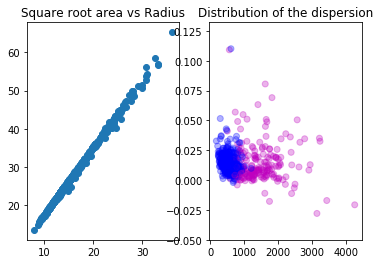

```python
#square root and correlation
sqrt_area_worst = data.area_worst**(0.5)

print(' --- Correlations: ---')
print("correlation between root area and radius: ",'{:.2%}'.format(np.corrcoef(data.radius_worst, sqrt_area_worst)[0][1]))
print("correlation between perimeter and radius: ",'{:.2%}'.format(np.corrcoef(data.perimeter_worst, data.radius_worst)[0][1]))


#comparison with cicle values

fract_peri = 2*math.pi*data.radius_worst/data.perimeter_worst-1
fract_area = np.sqrt(math.pi)*data.radius_worst/sqrt_area_worst-1
print(' --- Comparison between theoretical circle values and observed data: ---')
print('average distance between circle perimeter and observed perimeter: ','{0:.3f}'.format(np.mean(fract_peri)))
print('average distance between circle area and observed area: ','{0:.3f}'.format(np.mean(fract_area)))

#any pattern with diagnosis?
fig, axes = plt.subplots(nrows=1, ncols=2)

axes[0].set_title('Square root area vs Radius')
axes[0].scatter(data.radius_worst,sqrt_area_worst)
axes[1].set_title('Distribution of the dispersion')
axes[1].scatter(x=data.area_worst,y=fract_area, c = data.diagnosis, alpha =0.3)
#plt.scatter(x=data.perimeter_worst,y=deformation, c = data.diagnosis, alpha =0.3)
#plt.scatter(x=data.area_worst,y=fract2, c = data.diagnosis, alpha =0.3)
```

This confirms the intuition: there is a direct linear relationship between radius and perimeter (99.3%) and a quadratic one between radius and area (99.8%).

I also explored visually if the deviance from a round shape could bring any information about the diagnosis (right plot) but could not find anything significant.

# Predictive analysis

## Data preparation

First, let's split the dataset between **train** and **test**. Because the datset is quite small, I will only keep 15% of the observations as test set, that's a random sample of 86 observations, 32 of which (37%) are expected to be malignant.

```python
from sklearn.model_selection import cross_val_score
from sklearn.metrics import confusion_matrix
from sklearn import preprocessing
from sklearn.model_selection import train_test_split
np.random.seed(2018)

#split between target and predictors, test and train set
response = data['diagnosis']
variables = data.drop('diagnosis',axis=1)


xtrain, xtest,ytrain,ytest = train_test_split(variables, response,test_size=0.15)
```

Preprocessing: **Normalise**, **scale** and **standardize**

```python
from sklearn import preprocessing
#fit on the train set ==> I will use later in a pipeline
#p = Pipeline([
scaler = preprocessing.StandardScaler().fit(xtrain)
normalizer = preprocessing.Normalizer().fit(xtrain)

#PCA
```

```python
#Preprocessing: standardize and scale + normalize
from sklearn.preprocessing import StandardScaler, Normalizer
from sklearn.pipeline import make_pipeline

preproc = make_pipeline(StandardScaler(),Normalizer())
#fit on train, the transfo will be applied on both train and test
preproc.fit(xtrain)

#PCA?
```

```
Pipeline(memory=None,
     steps=[('standardscaler', StandardScaler(copy=True, with_mean=True, with_std=True)), ('normalizer', Normalizer(copy=True, norm='l2'))])
```

```python
preproc.transform(xtrain)
preproc.transform(xtest)
```

```
array([[-0.01813128, -0.17329796, -0.0285842 , ..., -0.2646842 ,
        -0.35098745, -0.18322403],
       [ 0.15080929,  0.04432646,  0.12993263, ..., -0.08303587,
         0.56605744, -0.08526175],
       [-0.20633885,  0.12451288, -0.21217072, ..., -0.27032176,
         0.02801997, -0.17137743],
       ...,
       [-0.03123621, -0.07482806, -0.04987446, ..., -0.21419343,
        -0.20125971, -0.25918521],
       [-0.11565311, -0.2689087 , -0.11733319, ..., -0.08101763,
         0.05207644, -0.10532911],
       [-0.0592531 , -0.21104455, -0.04823143, ...,  0.1128009 ,
        -0.07313664,  0.31917988]])
```

```python
from sklearn.preprocessing import label_binarize
#encoded_column_vector = label_binarize(ytrain, classes=['B','M']) # ham will be 0 and spam will be 1
#ytrain = np.ravel(encoded_column_vector) # Reshape array
#encoded_column_vector = label_binarize(ytest, classes=['B','M']) # ham will be 0 and spam will be 1
#ytest = np.ravel(encoded_column_vector) # Reshape array
#find a more straightforward way with LabelBinarizer()  - format issue



#lb = LabelBinarizer()
#y_train = np.array([number[0] for number in lb.fit_transform(y_train)])
```

```python
type(ytrain[0])
```

```
str
```

```python
print(xtrain.shape)
print(xtest.shape)
print(ytrain.shape)
print(ytest.shape)
```

```
(483, 30)
(86, 30)
(483,)
(86,)
```

## Performance measurement strategy

A comonly used performance metric is the classification **accuarcy**, defined as the percentage of observation correctly classified. A naive algorithm that would classify every observation as benigh would achieve a 63% accuracy on this dataset.

Because of the nature of this dataset, we will focus on the ability of the algorithms to detect malignant cells, with a trade-off for mis-diagnosis of non-cancerous patients.

We are more ready to accept that, at the cost of a stressful experience, a patient would be sent to additional sreening before being cleared for breat cancer (**False Positive**), than to accept the risk that a patient would not receive a treatement for breast cancer when needed (False Negative)

For this strategy, we will compare the different classification algorithms based on the following metrics:

**Sensitivity / Recall**

This is the algorithm ability to detect positives when the result is actually positive. More formally:

$Sensitivity = \frac{True \ Positives}{True \ Positives \ + \ False \ Negatives} = \frac{Number \ of \ malignant \ cells \ detected \ as \ malignant}{Total \ number \ of \ malignant \ cells}$

**F1 Score**

This is the balance between precision (percentage of true positives among results predicted as positive) and recall. weighted harmonic mean of the precision and recall

$F1 = 2 \ \times \frac{precision \ \times \ recall}{precision \ + \ recall}$

## First round of predictive analysis

```python
# initialize the matrix of results
name = []
meanCV = []
stdCV = []
testRecall = []
testF1 = []
runtime = []
folds = []


comparison = []
#load the required modules
from sklearn.model_selection import GridSearchCV,cross_val_score,KFold

from sklearn.metrics import make_scorer, accuracy_score, precision_score, recall_score, f1_score,classification_report

#create my own confusion matrix (I find the default one too basic)
def ConfusionMatrix(ytrue, ypred):
    matrix = pd.crosstab(ytrue, ypred, rownames=['True'], colnames=['Predicted'], margins=True)
    return matrix

#define a function that will retrieve cross val results in grid search
def CrossValResult(nfold,grid):
    b=np.zeros(nfold)#init output array
    for i in range(nfold):
        b[i]=grid.cv_results_['split'+ str(i) +'_test_score'][grid.best_index_]
    return b
```

```python
#set seed
seed = 2018

#define the cross validation method - 10 fold cross validation
kfold = KFold(n_splits=10, random_state=seed, shuffle= True)

#Define the scoring function
#This is required to specify that the positive label is 'M'
Recall_M = make_scorer(recall_score, greater_is_better=True,  pos_label='M')
F1_M = make_scorer(f1_score, greater_is_better=True,  pos_label='M')
```

### Naive Bayes

```python
#Naive bayes
from sklearn.naive_bayes import GaussianNB
model = GaussianNB()

#No hyperparameter tuning, I use the default ones
t0 = time.time()
%timeit model.fit(xtrain, ytrain);
cv_results = cross_val_score(model, xtrain, ytrain, cv=kfold,scoring=Recall_M )
t1 = time.time()
print('Recall on Train set: ', cv_results.mean())

#test set
ypred = model.predict(xtest)

#results
cm=ConfusionMatrix(ytest, ypred)
print('Confusion Matrix')
print(cm)
recall = recall_score(ytest, ypred,pos_label='M')
print('Recall on Test set: ' , recall)
print('Classification Report')
print(classification_report(ytest, ypred))
#sns.heatmap(cm, square=True, annot=True, fmt='d', cbar=False)

#table with all results for comparison
name.append('Naive Bayes')
meanCV.append(cv_results.mean())
stdCV.append(cv_results.std())
testRecall.append(recall)
testF1.append(f1_score(ytest, ypred,pos_label='M'))
runtime.append(t1-t0)
folds.append(cv_results)
```

```
1.12 ms ± 123 µs per loop (mean ± std. dev. of 7 runs, 1000 loops each)
Recall on Train set:  0.9080799755799756
Confusion Matrix
Predicted   B   M  All
True
B          50   8   58
M           3  25   28
All        53  33   86
Recall on Test set:  0.8928571428571429
Classification Report
             precision    recall  f1-score   support

          B       0.94      0.86      0.90        58
          M       0.76      0.89      0.82        28

avg / total       0.88      0.87      0.87        86
```

```python
cv_results
```

```
array([0.92307692, 0.95833333, 0.86666667, 0.92307692, 0.94444444,
       0.84615385, 0.83333333, 0.92857143, 0.85714286, 1.        ])
```

### Support vector machine

```python
from sklearn.svm import SVC #support vector classifier
model=SVC()
#
# param_grid = [
#     {'C': [1, 10, 100, 1000], 'kernel': ['rbf']}
#     ]
param_grid = [
    {'C': [1, 10, 100, 1000], 'kernel': ['rbf'],'gamma':[0.01,0.001,0.0001,0.00001]}]

#gamma: shape of the hyperplane
#C: Cost function, the highest the hardest the margins
#grid = GridSearchCV(model, param_grid,cv=10,scoring='recall',n_jobs = -1)
grid = GridSearchCV(model, param_grid,cv=kfold,n_jobs = -1,scoring=Recall_M)
t0 = time.time()
grid.fit(xtrain,ytrain)
t1=time.time()
print('Run time: ',t1-t0)


#results form cross validation
print('Tuning: ',grid.best_params_)
mean = grid.cv_results_['mean_test_score'][grid.best_index_]
std = grid.cv_results_['std_test_score'][grid.best_index_]
print('Recall on train set: ',mean)

#fit on validation set
ypred = grid.predict(xtest)
recall = recall_score(ytest, ypred,pos_label='M')
print('Recall on test set: ',recall)
cm=ConfusionMatrix(ytest, ypred)
print('Confusion Matrix')
print(cm)

#summary
name.append('SVM')
meanCV.append(mean)
stdCV.append(std)
testRecall.append(recall)
testF1.append(f1_score(ytest, ypred,pos_label='M'))
runtime.append(t1-t0)
folds.append(CrossValResult(kfold.n_splits,grid))
```

```
Run time:  36.54240107536316
Tuning:  {'C': 1000, 'gamma': 1e-05, 'kernel': 'rbf'}
Recall on train set:  0.9315363380580772
Recall on test set:  0.8928571428571429
Confusion Matrix
Predicted   B   M  All
True
B          55   3   58
M           3  25   28
All        58  28   86
```

### Logistic regression

```python
from sklearn.linear_model import LogisticRegression
model=LogisticRegression()

t0= time.time()
%timeit model.fit(xtrain, ytrain);
cv_results = cross_val_score(model, xtrain, ytrain, cv=kfold,scoring=Recall_M )
t1 = time.time()
print('Recall on Train set: ', cv_results.mean())

#test set
ypred = model.predict(xtest)

#results
recall = recall_score(ytest, ypred,pos_label='M')
print('Recall on Test set: ' , recall)
cm=ConfusionMatrix(ytest, ypred)
print('Confusion Matrix')
print(cm)

#Create summary
name.append('Logistic regression')
meanCV.append(cv_results.mean())
stdCV.append(cv_results.std())
testRecall.append(recall)
testF1.append(f1_score(ytest, ypred,pos_label='M'))
runtime.append(t1-t0)
folds.append(cv_results)
```

```
6.41 ms ± 143 µs per loop (mean ± std. dev. of 7 runs, 100 loops each)
Recall on Train set:  0.9371291208791209
Recall on Test set:  0.8928571428571429
Confusion Matrix
Predicted   B   M  All
True
B          55   3   58
M           3  25   28
All        58  28   86
```